# Ptychodera Cisreg Development: Differential Gene Expression Analysis

## Clustering of the developmental stages

To check how many broad groups of developmental stages we can identify at the transcriptomic level, we cluster these stages.

```r
pf_spe_hm_clu <-
  Heatmap(
    rna_counts_sp,
    name="Spearman",
    top_annotation=devstages_ha_columns_simple(),
    left_annotation=devstages_ha_rows(),
    cluster_rows = TRUE,
    cluster_columns = TRUE,
    show_row_names=F,
    show_column_names=F,
    col=colorRampPalette(rev(brewer.pal(7,"RdYlBu")))(100)
  )

dend <- row_dend(pf_spe_hm_clu)
labels_colors(dend) <- dev_palette[order.dendrogram(dend)]

pdf("graphics/Supp_1_2_1.pdf", he = 4.5, wi = 5)
draw(pf_spe_hm_clu)
dev.off()
```

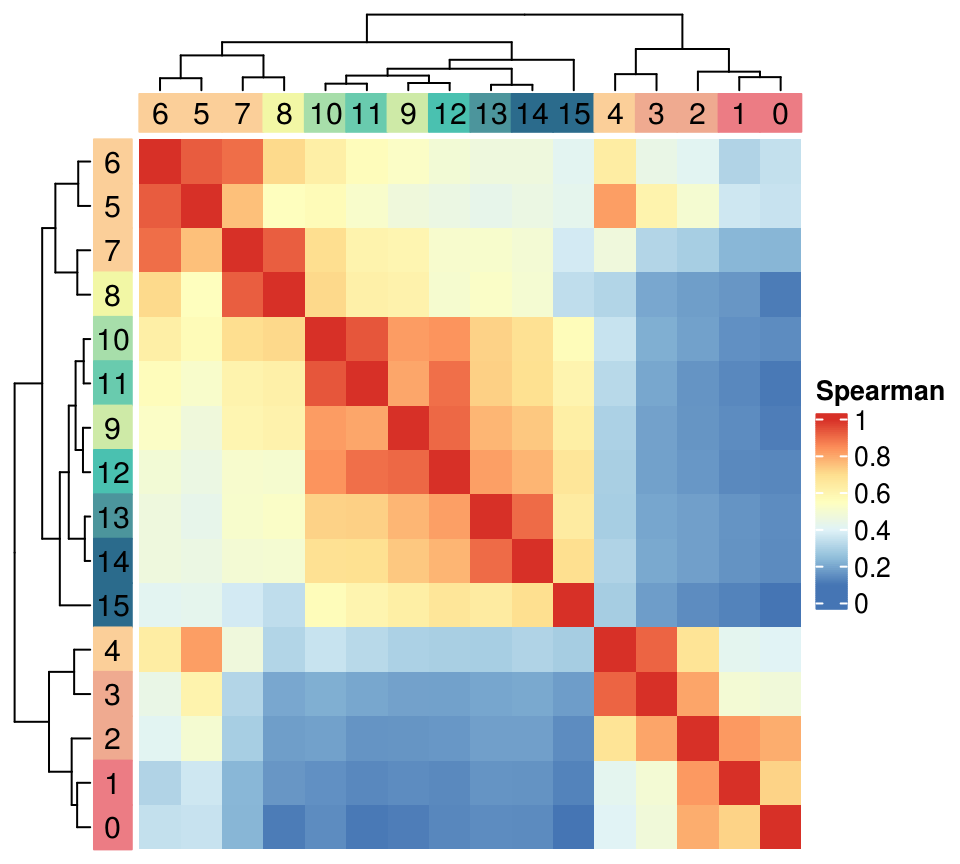

```r
draw(pf_spe_hm_clu)
```

```r
# Levy et al 2021 'treeFromEnsembleClustering' from source
pf_counts <- sapply(
  levels(condition_x),
  rowMeans_by_repl,
  pfla_rna_counts
)
pf_counts_cooc = tidyup(pf_counts, highlyvariable = T)

set.seed(4343) # fixed seed, important
h <- c(0.75,0.95)
clustering_algorithm <- "hclust"
clustering_method <- "average"
cor_method <- "pearson"
p <- 0.1
vargenes = rownames(pf_counts_cooc)

cooc <- treeFromEnsembleClustering(
  x=pf_counts_cooc, p=p, h=h,  n = 1000, vargenes = vargenes, bootstrap=FALSE,
  clustering_algorithm=clustering_algorithm, clustering_method=clustering_method,
  cor_method=cor_method
)
```

```r
dend2 <- as.dendrogram(cooc$tree)
labels_colors(dend2) <- dev_palette[order.dendrogram(dend2)]

col_cooc <-
  colorRamp2(
    seq(min(cooc$cooccurrence),max(cooc$cooccurrence),length=9),
    colors=c(
      "white",'#ffffe5','#fff7bc','#fee391','#fec44f',
      '#fe9929','#ec7014','#cc4c02','#990000'
      )
    )

pfla_rna_cooc <- Heatmap(
  name="co-occurence",
  cooc$cooccurrence,
  col = col_cooc,
  cluster_rows = as.hclust(cooc$tree),
  cluster_columns = as.hclust(cooc$tree),
  left_annotation = devstages_ha_rows(),
  top_annotation = devstages_ha_columns_simple(),
  row_names_gp = gpar(fontsize = 8),
  column_names_gp = gpar(fontsize = 8)
)

pdf("graphics/Supp_1_2_3.pdf", he = 4.5, wi = 5)
draw(pfla_rna_cooc)
dev.off()
```

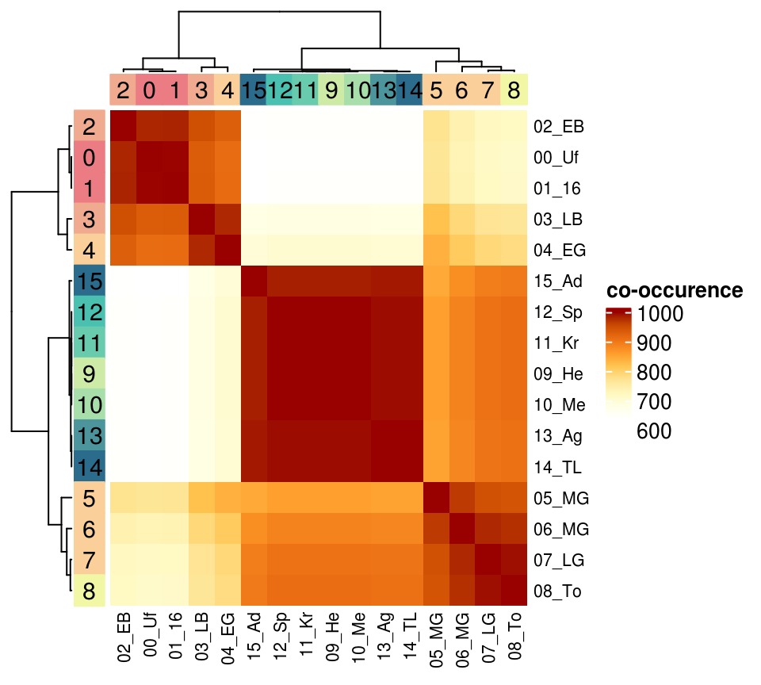

```r
draw(pfla_rna_cooc)
```

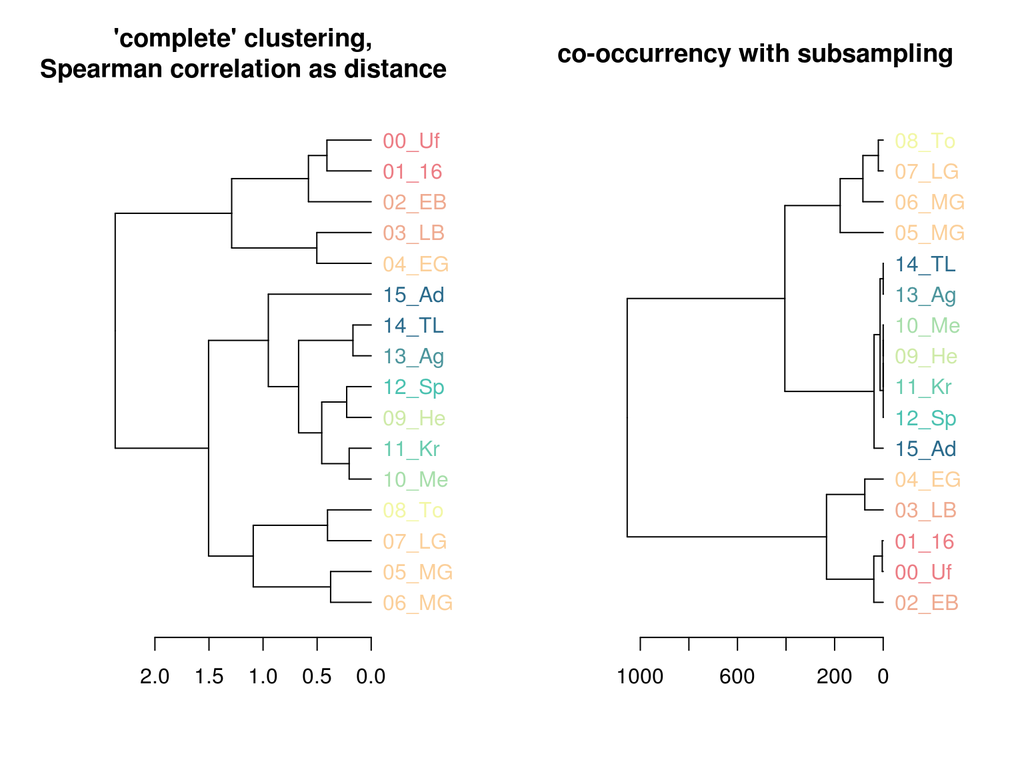

```r
par(mar = c(5, 4, 4, 5) + 0.1, mfrow = c(1,2))
plot(dend, horiz = T, main = "'complete' clustering,\nSpearman correlation as distance")
plot(dend2, horiz = T, main = "co-occurrency with subsampling")
```

```r
par(mar = c(5, 4, 4, 2) + 0.1, mfrow = c(1,1))

pdf("graphics/Supp_1_2_3.pdf", he = 6, wi = 8)
par(mar = c(5, 4, 4, 5) + 0.1, mfrow = c(1,2))
plot(dend, horiz = T, main = "'complete' clustering,\nSpearman correlation as distance")
plot(dend2, horiz = T, main = "co-occurrency with subsampling")
par(mar = c(5, 4, 4, 2) + 0.1, mfrow = c(1,1))
dev.off()
```

And a glimpse of the highest values of correlations as a graph connecting the different developmental stages:

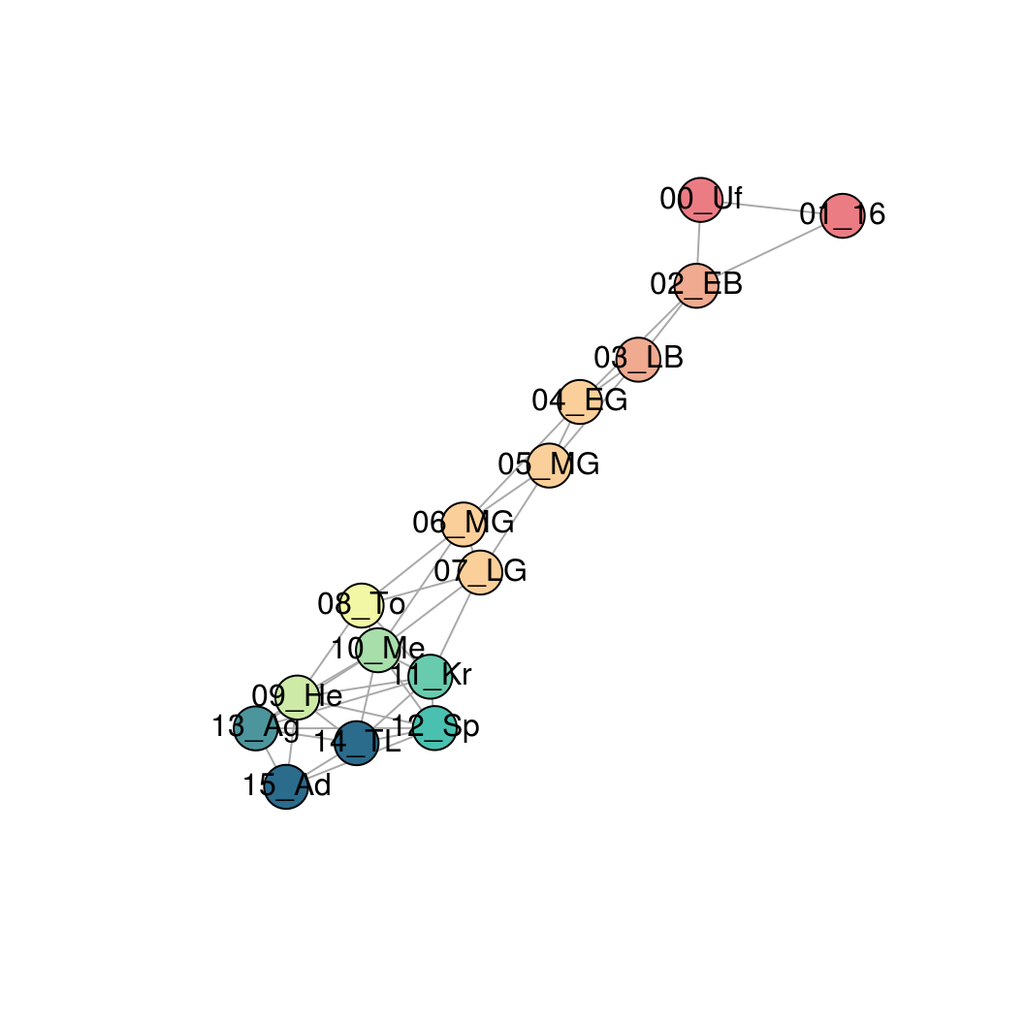

```r
library(igraph)
g_stages <-
  graph_from_adjacency_matrix(
    rna_counts_sp, mode = "upper", weighted = TRUE, diag = FALSE
  )
thresh = .6
g_stages <-
  subgraph.edges(
    g_stages,
    E(g_stages)[E(g_stages)$weight > thresh]
    )

V(g_stages)$color <-
  translate_ids(
    x = V(g_stages)$name,
    dict =
      data.frame(
        stage = levels(condition_x),
        col = dev_palette
      )
  )

set.seed(1234)
plot(g_stages, vertex.label.family = "Helvetica", vertex.label.color = "black")
```

```r
pdf("graphics/Supp_1_2_4.pdf", he = 5.5, wi = 5.5)
set.seed(1234)
plot(g_stages, vertex.label.family = "Helvetica", vertex.label.color = "black")
dev.off()
```

## DESeq2 analysis

We will import the RUV-normalised counts to DESeq2 following the design matrix we generated before.

```r
dds <-
  DESeqDataSetFromMatrix(
    countData = pfla_rna_counts,
    colData = pData(set2),
    design = ~ W_1 + condition_x
    )
```

[output not shown]

```r
dds <- estimateSizeFactors(dds)

nc <- counts(dds, normalized=TRUE)

filter <- rowSums(nc >= 10) >= 2

dds <- dds[filter,]
```

Estimation of factor sizes and the dispersion

```r
dds <- estimateSizeFactors(dds)
dds <- estimateDispersions(dds)
```

The likelihood-ratio test is the proper one for time-series analysis.

```r
dds <-
  nbinomLRT(
    dds,
    reduced=as.formula("~ W_1"),
    maxit=500
    )
```

```
## 22 rows did not converge in beta, labelled in mcols(object)$fullBetaConv. Use larger maxit argument with nbinomLRT
```

And the results:

```r
res <- results(dds)

round(data.frame(res)[1:10,],3)
```

```
##                baseMean log2FoldChange  lfcSE    stat pvalue  padj
## TCONS_00038693    8.825        -30.000 11.025  64.209  0.000 0.000
## TCONS_00038695   67.115         12.443  5.658  50.968  0.000 0.000
## TCONS_00038635  188.863        -15.146  6.443 114.607  0.000 0.000
## TCONS_00038698   16.714         -4.013 11.599  42.223  0.000 0.000
## TCONS_00038700   64.983          0.692  4.345 108.500  0.000 0.000
## TCONS_00038637    3.870          7.198  9.645  31.267  0.008 0.010
## TCONS_00038702  276.381         -0.046  3.827 326.374  0.000 0.000
## TCONS_00038639   40.041         16.956  3.485 175.549  0.000 0.000
## TCONS_00038704    9.058        -16.827 14.308  10.751  0.770 0.824
## TCONS_00038706    6.374        -11.054 12.091  25.743  0.041 0.049
```

```r
cutoff=0.05

res_signif <-
  subset(res, padj < cutoff )

head(apply(res_signif,2,round,digits=3))
```

```
##                baseMean log2FoldChange  lfcSE    stat pvalue padj
## TCONS_00038693    8.825        -30.000 11.025  64.209  0.000 0.00
## TCONS_00038695   67.115         12.443  5.658  50.968  0.000 0.00
## TCONS_00038635  188.863        -15.146  6.443 114.607  0.000 0.00
## TCONS_00038698   16.714         -4.013 11.599  42.223  0.000 0.00
## TCONS_00038700   64.983          0.692  4.345 108.500  0.000 0.00
## TCONS_00038637    3.870          7.198  9.645  31.267  0.008 0.01
```

To proceed with data visualisation and clustering analysis, we will use the variance-stabilised transform of this data.

```r
# Variance-stabilised transformation
vsd <- vst(dds)

# Assay with all genes
vsd_allgen <-
  as.data.frame(
    assay(vsd)
    )

# Assay with only significant genes
vsd_signif <-
  as.data.frame(
    assay(
      vsd[rownames(vsd) %in% rownames(res_signif),]
      )
    )
```

To summarise our data, we will calculate the arithmetic mean across columns that are replicates from the same developmental stage using a custom function. Thus we end up with:

```r
pfla_rna_all <-
    as.data.frame(
    sapply(
      levels(condition_x),
      rowMeans_by_repl,
      vsd_allgen # all genes
      )
  )

rownames(pfla_rna_all) <- rownames(vsd_allgen)

pfla_rna_dev <-
  data.frame(
    sapply(
      levels(condition_x),
      rowMeans_by_repl,
      vsd_signif # significantly regulated throughout develompent
      )
  )

rownames(pfla_rna_dev) <- rownames(vsd_signif)

pfla_rna_dev[1:5,1:5]
```

```
##                  X00_Uf   X01_16   X02_EB   X03_LB   X04_EG
## TCONS_00038693 5.567399 5.611226 4.837948 3.456325 3.392000
## TCONS_00038695 3.554766 3.270354 4.576883 4.821917 3.918621
## TCONS_00038635 6.999481 6.838503 6.420595 4.366532 4.042444
## TCONS_00038698 2.864685 2.864685 6.019735 6.768770 5.621874
## TCONS_00038700 9.702506 7.279891 6.090447 6.110012 5.816929
```

We can cluster our data to detect patterns of gene expression during development.

```r
pfla_rna_dev_hc <-
  hclust(
    dist(t(scale(t(pfla_rna_dev)))),
    method = "ward.D2"
  )
```

We pick a threshold to cut around distance “50”.

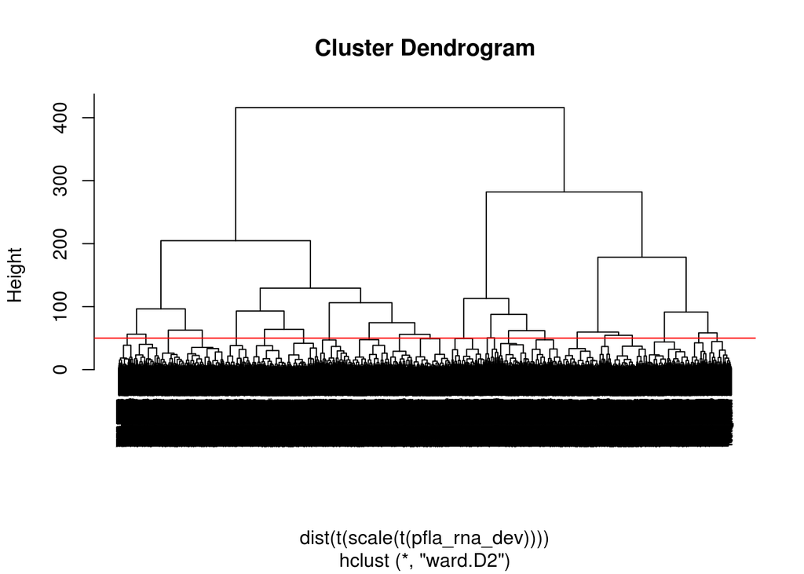

```r
plot(pfla_rna_dev_hc,cex=0.3)

cutoff = 50
abline(cutoff, 0, col="red")
```

And we proceed to binning the genes in clusters:

```r
pfla_rna_dev$clusterID <-
  cutree(pfla_rna_dev_hc, h = cutoff)

unique(pfla_rna_dev$clusterID)
```

```
##  [1]  1  2  3  4  5  6  7  8  9 10 11 12 13 14 15 16 17 18 19 20 21 22
```

We manually rearranged these clusters and provided new IDs.

```r
hclu_names <-
  read.table(
    "assets/rna_dev_hcluster_name_equiv.tsv",
    header = F,
    col.names = c("clusterID","cID"),
    colClasses = c("numeric","character")
  )

pfla_rna_dev$cID <-
  hclu_names$cID[
    match(
      pfla_rna_dev$clusterID,
      as.integer(hclu_names$clusterID)
      )
    ]

#remove old numbering
pfla_rna_dev$clusterID <- NULL
```

We will subsample this gigantic dataset to retrieve a few genes per cluster in order to see their dynamics during development.

```r
set.seed(2)

pfla_rna_dev_viz <-
  pfla_rna_dev[
    sample(
      nrow(pfla_rna_dev),
      200
    ),
  ]
```

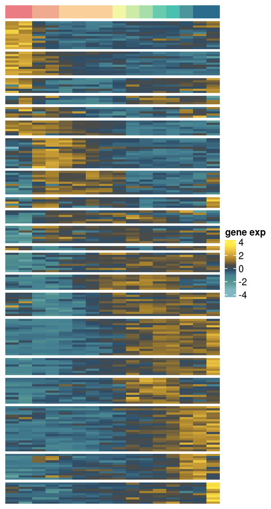

```r
pf_hm <-
  Heatmap(
    t(scale(t(pfla_rna_dev_viz[,1:16]))),
    name = "gene exp",
    top_annotation=devstages_ha_columns(),
    row_split=pfla_rna_dev_viz$cID,
    show_row_names = F,
    show_column_names=F,
    cluster_rows=F,
    cluster_columns=F,
    column_names_side="top",
    row_title = NULL,
    col=app_pal1,
    use_raster = F
  )

draw(pf_hm)
```

A tidier visualisation of the clusters that we will use throughout the manuscript. This is achieved averaging the expression profile of all genes of each clusters.

```r
pfla_rna_dev_avg <-
  data.frame(
    aggregate(
      t(scale(t(pfla_rna_dev[,1:16]))),
      by = list(cluster = pfla_rna_dev$cID),
      FUN = mean
    )[-1],
    row.names = sort(unique(pfla_rna_dev$cID))
  )
```

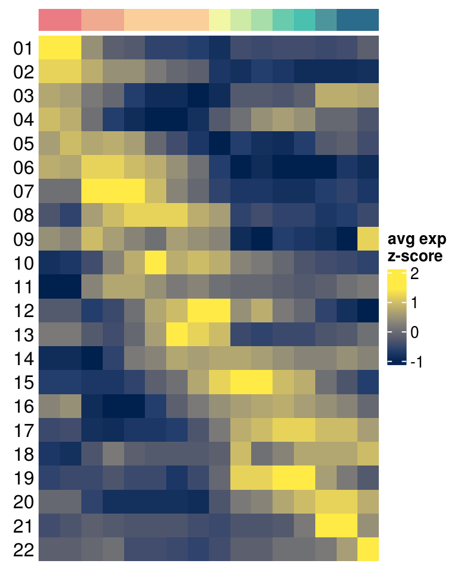

```r
pf_avg_hm <-
  Heatmap(
    name="avg exp\nz-score",
    as.matrix(quantile_normalisation(pfla_rna_dev_avg)),
    show_row_names = TRUE,
    row_names_side = "left",
    show_column_names = F,
    cluster_rows=F,
    cluster_columns=F,
    top_annotation=devstages_ha_columns(),
    column_names_side="top",
    row_title = NULL,
    col=cividis(7)
  )

draw(pf_avg_hm)
```

```r
pdf(
  file = "graphics/1D.pdf",
  height = 7.5,
  width = 4
)
draw(pf_avg_hm)
dev.off()
```